# Cwong Assign11

Calvin Wong

4/13/2019

Using the “cars” dataset in R, build a linear model for stopping distance as a function of speed and replicate the analysis of your textbook chapter 3 (visualization, quality evaluation of the model, and residual analysis.)

```r
data(mtcars)
head(mtcars, 6)
```

```
##                    mpg cyl disp  hp drat    wt  qsec vs am gear carb
## Mazda RX4         21.0   6  160 110 3.90 2.620 16.46  0  1    4    4
## Mazda RX4 Wag     21.0   6  160 110 3.90 2.875 17.02  0  1    4    4
## Datsun 710        22.8   4  108  93 3.85 2.320 18.61  1  1    4    1
## Hornet 4 Drive    21.4   6  258 110 3.08 3.215 19.44  1  0    3    1
## Hornet Sportabout 18.7   8  360 175 3.15 3.440 17.02  0  0    3    2
## Valiant           18.1   6  225 105 2.76 3.460 20.22  1  0    3    1
```

I would like to test if mpg has any influence on qsec. I believe cars with a lower mpg have larger engines and therefore have better quarter-mile times. Let’s test this theory.

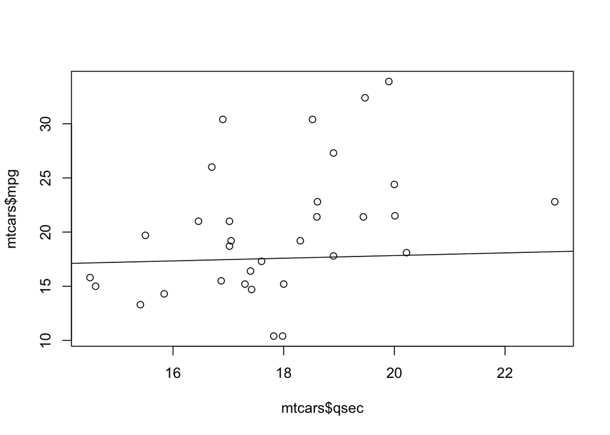

```r
qsecmpg <- lm(mtcars$qsec ~ mtcars$mpg)
plot(mtcars$qsec,mtcars$mpg)
abline(qsecmpg)
```

This linear model seems to fit my theory. Lets use regression to see if we can strengthen the case.

```r
summary(qsecmpg)
```

```
##
## Call:
## lm(formula = mtcars$qsec ~ mtcars$mpg)
##
## Residuals:
##     Min      1Q  Median      3Q     Max
## -2.8161 -1.0287  0.0954  0.8623  4.7149
##
## Coefficients:
##             Estimate Std. Error t value Pr(>|t|)
## (Intercept) 15.35477    1.02978  14.911 2.05e-15 ***
## mtcars$mpg   0.12414    0.04916   2.525   0.0171 *
## ---
## Signif. codes:  0 '***' 0.001 '**' 0.01 '*' 0.05 '.' 0.1 ' ' 1
##
## Residual standard error: 1.65 on 30 degrees of freedom
## Multiple R-squared:  0.1753, Adjusted R-squared:  0.1478
## F-statistic: 6.377 on 1 and 30 DF,  p-value: 0.01708
```

In this case, the y-intercept is a0 = 15.3548 and the slope is a1 = 0.1241. Thus, the final regression model is:

qsec = 15.3548 + 0.1241 * mpg

The reported R2 of 0.1753 for this model means that the model only explains 17.53 percent of the data’s variation.

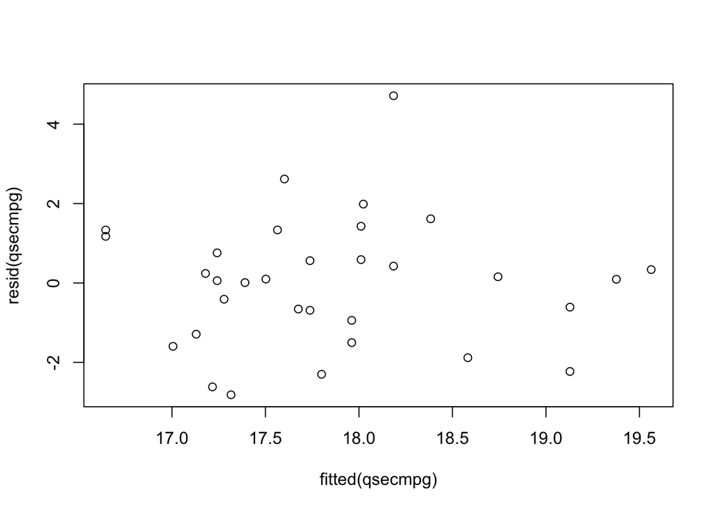

```r
plot(fitted(qsecmpg),resid(qsecmpg))
```

Overall, this plot tells us that using the mpg as the sole predictor in the regression model does not sufficiently or fully explain the data. There is no observable trend or pattern in the residuals.

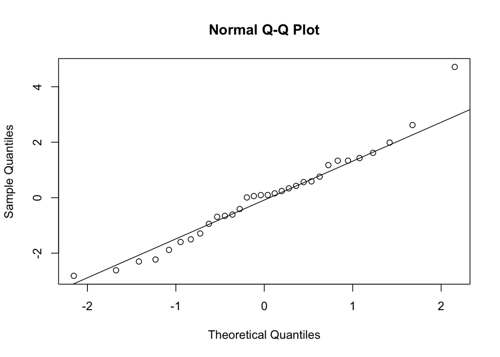

```r
qqnorm(resid(qsecmpg))
qqline(resid(qsecmpg))
```

The residuals seem to be normally distributed, the points plotted in this figure seem to follow the straight line well.